# Adult Census Income Data Analysis

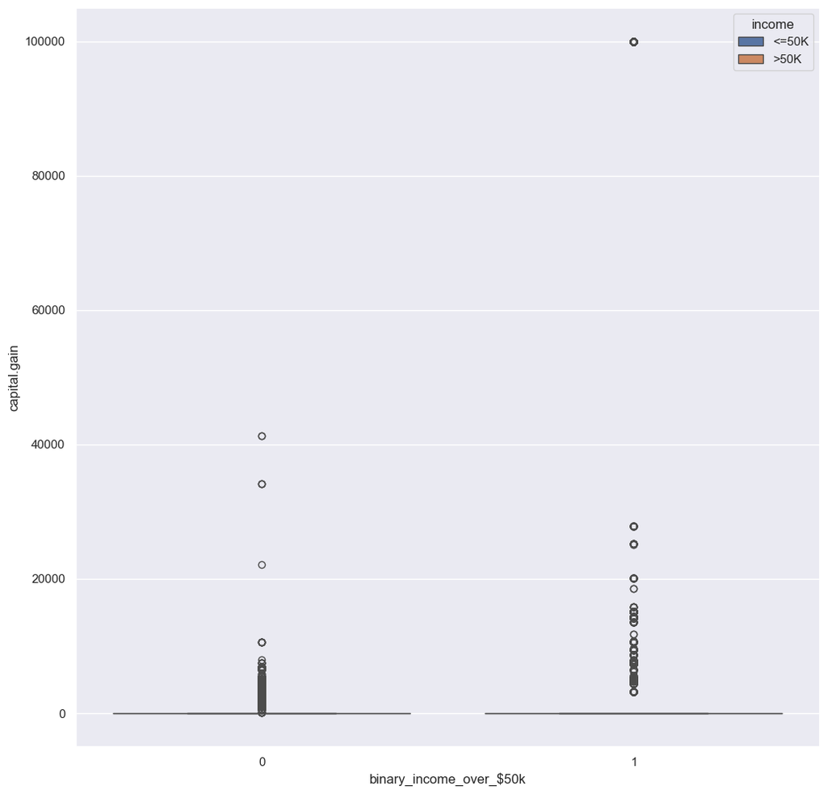

|  | Income <= 50k(0) | Income > 50k(1) |
| --- | --- | --- |
| count | 22654.000000 | 7508.000000 |
| mean | 148.893838 | 3937.679808 |
| std | 936.392280 | 14386.060019 |
| min | 0.000000 | 0.000000 |
| 25% | 0.000000 | 0.000000 |
| 50% | 0.000000 | 0.000000 |
| 75% | 0.000000 | 0.000000 |
| max | 41310.000000 | 99999.000000 |

```python
capital_gain_info = plot_boxplot(x = 'binary_income_over_$50k', y = 'capital.gain')
capital_gain_info
```

Once again, the quartiles for the boxplot have been squished to the bottom of the graph. The descriptive stats show that for the people who make > 50k, they have a mean of 3937.67 capital gain, while the people who make <= 50k have a mean of 148.89 capital gain. That is a sizeable difference between the two. The max value of capital gain is 41310.0 for people who make < 50k, and then for people who make > 50k it's 99999.0

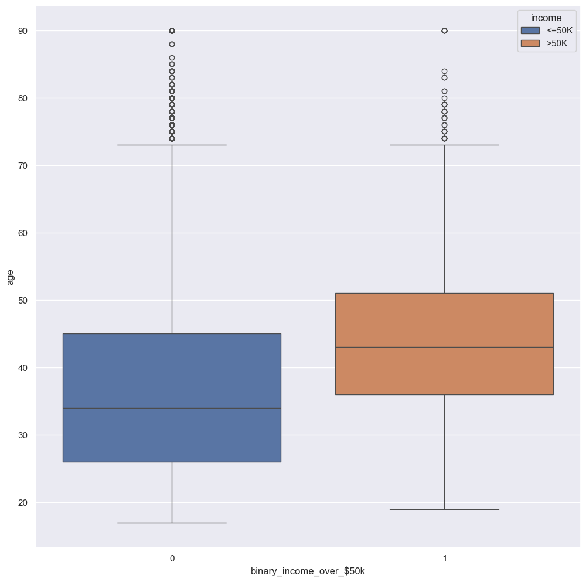

|  | Income <= 50k(0) | Income > 50k(1) |
| --- | --- | --- |
| count | 22654.000000 | 7508.000000 |
| mean | 36.608060 | 43.959110 |
| std | 13.464631 | 10.269633 |
| min | 17.000000 | 19.000000 |
| 25% | 26.000000 | 36.000000 |
| 50% | 34.000000 | 43.000000 |
| 75% | 45.000000 | 51.000000 |
| max | 90.000000 | 90.000000 |

```python
age_group_info = plot_boxplot(x = 'binary_income_over_$50k', y='age')
age_group_info
```

From the above figure and the statistics, the mean age of people who make > 50k is higher than the mean age of people who make <= 50k. With values of 43.95 years old and 36.60 years old, respectively.

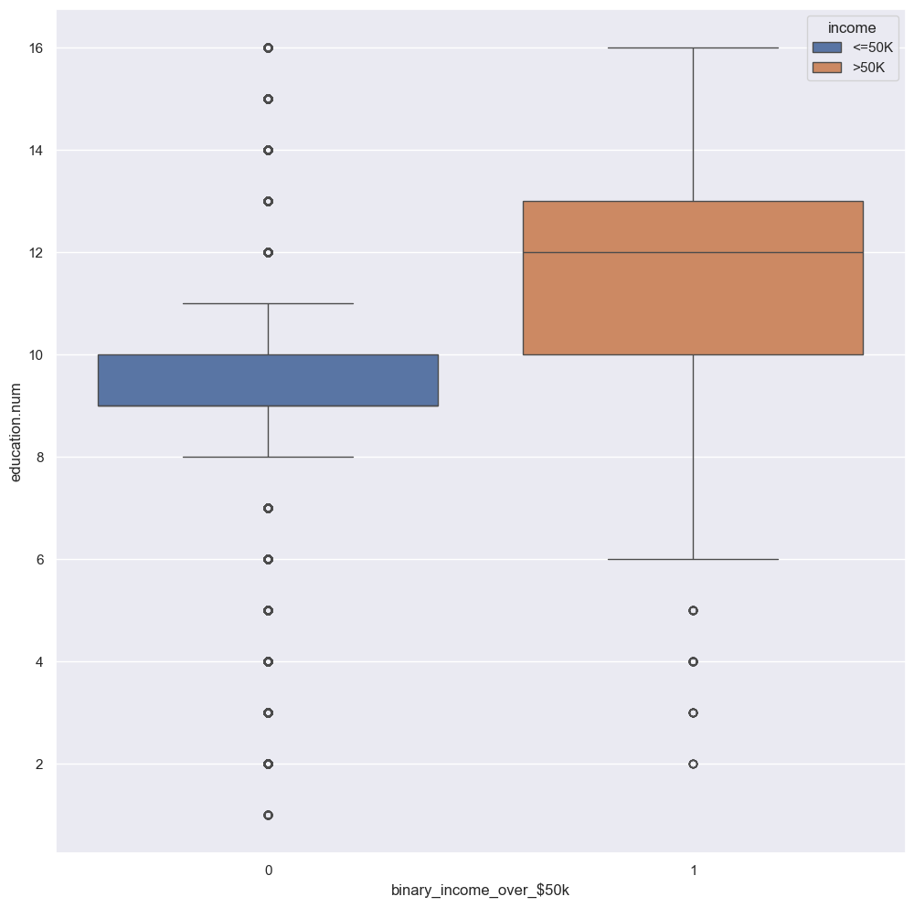

|  | Income <= 50k(0) | Income > 50k(1) |
| --- | --- | --- |
| count | 22654.000000 | 7508.000000 |
| mean | 9.629116 | 11.606420 |
| std | 2.413596 | 2.368423 |
| min | 1.000000 | 2.000000 |
| 25% | 9.000000 | 10.000000 |
| 50% | 9.000000 | 12.000000 |
| 75% | 10.000000 | 13.000000 |
| max | 16.000000 | 16.000000 |

```python
education_num_info = plot_boxplot(x = 'binary_income_over_$50k', y = 'education.num')
education_num_info
```

The above information tells us that the average education number for people who make > 50k is 12, if we round up to the nearest number, which is equivalent to Assoc-acdm in terms of education level. Then, for the people who make <= 50k, rounding up to the nearest whole number, the average education number is 10, meaning they have some-college. This answers analysis question #3, the average education level for both groups is now known.

### Numerical Columns Correlations

Next let's see how correlated the numerical columns are to each binary column.

```python
adult_census_data.corr(numeric_only= True)[['binary_income_over_$50k', 'binary_income_equal_under_$50k']]
```

|  | binary_income_over_$50k | binary_income_equal_under_$50k |
| --- | --- | --- |
| age | 0.241998 | -0.241998 |
| education.num | 0.335286 | -0.335286 |
| capital.gain | 0.221196 | -0.221196 |
| capital.loss | 0.150053 | -0.150053 |
| hours.per.week | 0.229480 | -0.229480 |
| binary_income_over_$50k | 1.000000 | -1.000000 |
| binary_income_equal_under_$50k | -1.000000 | 1.000000 |

From the correlation matrix analysis, question #4 and analysis question #6 can be answered. The correlation between capital gain and a person making over > 50k is 0.221, indicating a weak positive relationship. This makes sense since not everyone who is making money from investments might be making a profit compared to their losses, or the money made isn't much. The column with the highest amount of correlation, in terms of magnitude, for both binary columns is education.num with a value of 0.335. This is a weak relationship, indicating that as a person's education level becomes higher, they are more likely to make >50k. If we look at it from the perspective of making <= 50k, then it indicates that as a person's education level becomes higher than they are less likely to make <= 50k. Capital loss has the least amount of correlation with both of the income groups.

## Exploring qualtative columns

For visualizing the qualtative colums let's use bar chart to help answer the analysis questions. Let's get a list of the qualtative columns.

```python
adult_census_data.select_dtypes(include = 'object').columns
```

```
Index(['workclass', 'education', 'marital.status', 'occupation',
       'relationship', 'race', 'sex', 'native.country', 'income'],
      dtype='object')
```

```python
def plot_countplot(col: str, figsize = (15,15)) -> pd.DataFrame:
  """Creates a countplot and returns a frequency table that represents the countplot

  Args:
      col (str): A column name from adult_census_data

  Returns:
      pd.DataFrame: A Frequency table that represents the countplot that is made
  """
  fig, ax = plt.subplots(figsize=figsize)
  sns.countplot(x=adult_census_data[col], hue = adult_census_data['income'], ax=ax)
  plt.savefig(f'figures/{col}_countplot.png', dpi=300, bbox_inches='tight')
  plt.show()
  return pd.crosstab(index= adult_census_data[col], columns = adult_census_data['binary_income_over_$50k']) #creates a frequency table
```

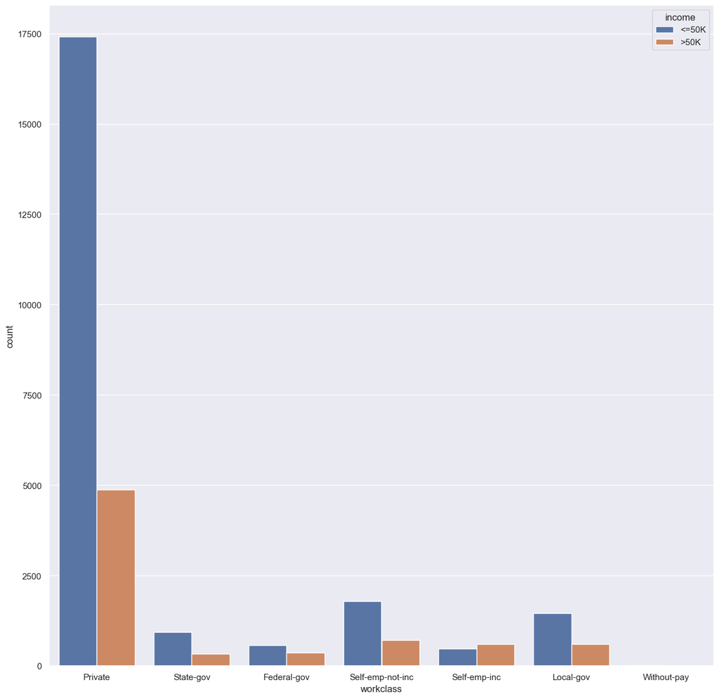

| binary_income_over_$50k workclass | 0 | 1 |
| --- | --- | --- |
| Private | 17410 | 4876 |
| Self-emp-not-inc | 1785 | 714 |
| Local-gov | 1458 | 609 |
| State-gov | 935 | 344 |
| Federal-gov | 578 | 365 |
| Self-emp-inc | 474 | 600 |
| Without-pay | 14 | 0 |

```python
workclass_countplot_table = plot_countplot('workclass')
workclass_countplot_table.sort_values(by=0, ascending = False) # sort by column 0 and go from largest to smallest
```

The above figure shows that the private workclass has the most amount of people making > 50k, as well as the most amount of people making less <= 50k. There are 4876 people who make > $50k and who are a part of the private workclass. This answers analysis question #7. A trend for the data is that the <= 50k income group has more people in it than the > 50k income group for every workclass, except for the self-emp-inc workclass.

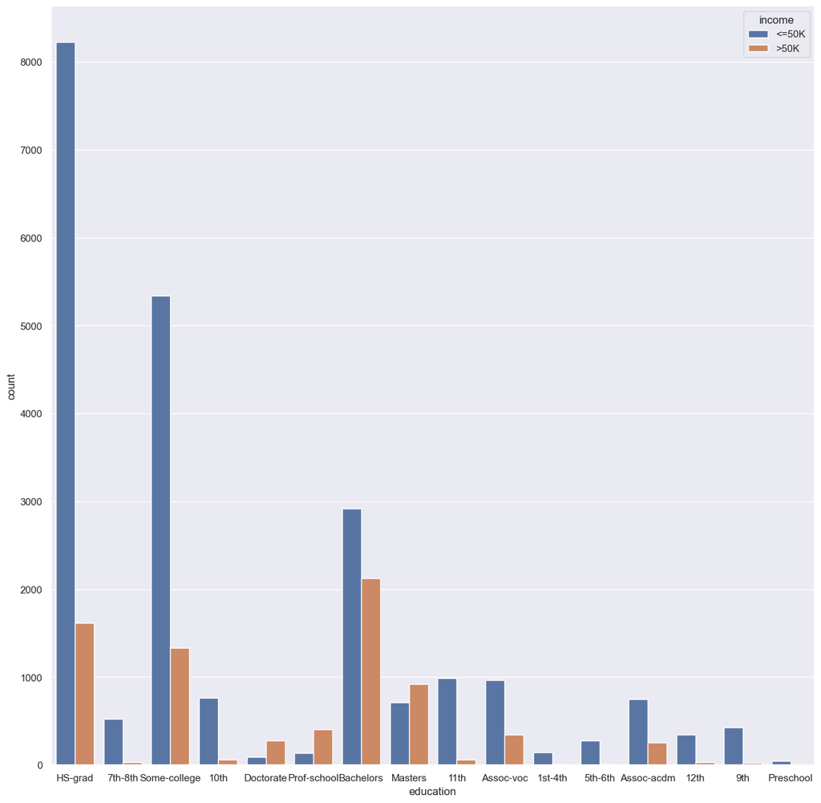

| binary_income_over_$50k education | 0 | 1 |
| --- | --- | --- |
| HS-grad | 8223 | 1617 |
| Some-college | 5342 | 1336 |
| Bachelors | 2918 | 2126 |
| 11th | 989 | 59 |
| Assoc-voc | 963 | 344 |
| 10th | 761 | 59 |
| Assoc-acdm | 752 | 256 |
| Masters | 709 | 918 |
| 7th-8th | 522 | 35 |
| 9th | 430 | 25 |
| 12th | 348 | 29 |
| 5th-6th | 276 | 12 |
| 1st-4th | 145 | 6 |
| Prof-school | 136 | 406 |
| Doctorate | 95 | 280 |
| Preschool | 45 | 0 |

```python
education_countplot_table = plot_countplot('education')
education_countplot_table.sort_values(by=0, ascending = False) # sort by column 0 and go from largest to smallest
```

It's clear that education level with the most amount of people who are making <= 50k is the HS-grad education level, from the above figure. We can also see that for post-graduate education levels, there is more people who make over >50k than there are people who make <= 50k. We can see the opposite effect for people whose highest education level is a Bachelor's degree or lower.

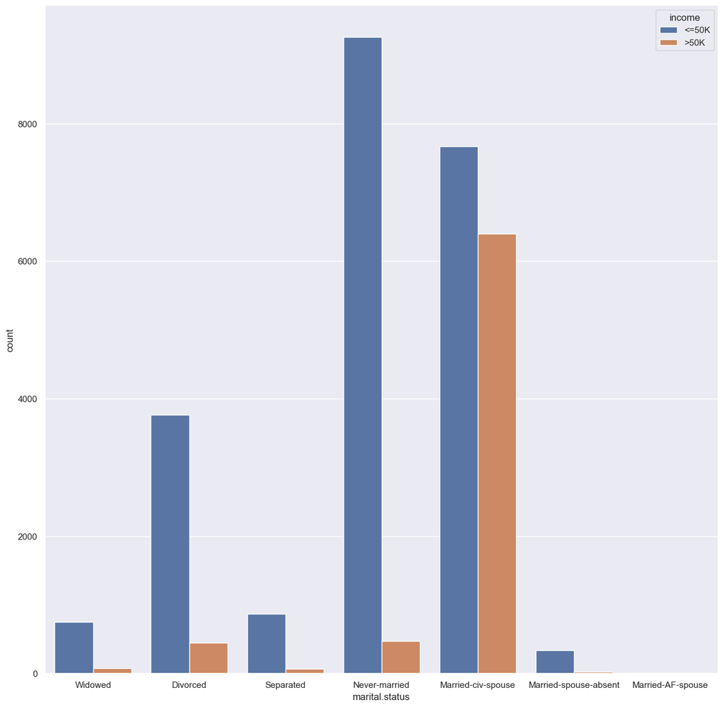

| binary_income_over_$50k marital.status | 0 | 1 |
| --- | --- | --- |
| Never-married | 9256 | 470 |
| Married-civ-spouse | 7666 | 6399 |
| Divorced | 3762 | 452 |
| Separated | 873 | 66 |
| Widowed | 747 | 80 |
| Married-spouse-absent | 339 | 31 |
| Married-AF-spouse | 11 | 10 |

```python
marital_status_countplot_table = plot_countplot('marital.status')
marital_status_countplot_table.sort_values(by=0, ascending = False) # sort by column 0 and go from largest to smallest
```

From the above figure, analysis question #5 can be answered. The marital status with the most amount of people making > 50k is married-civ-spouse. The marital status with the most amount of people making <= 50k is Never-married.

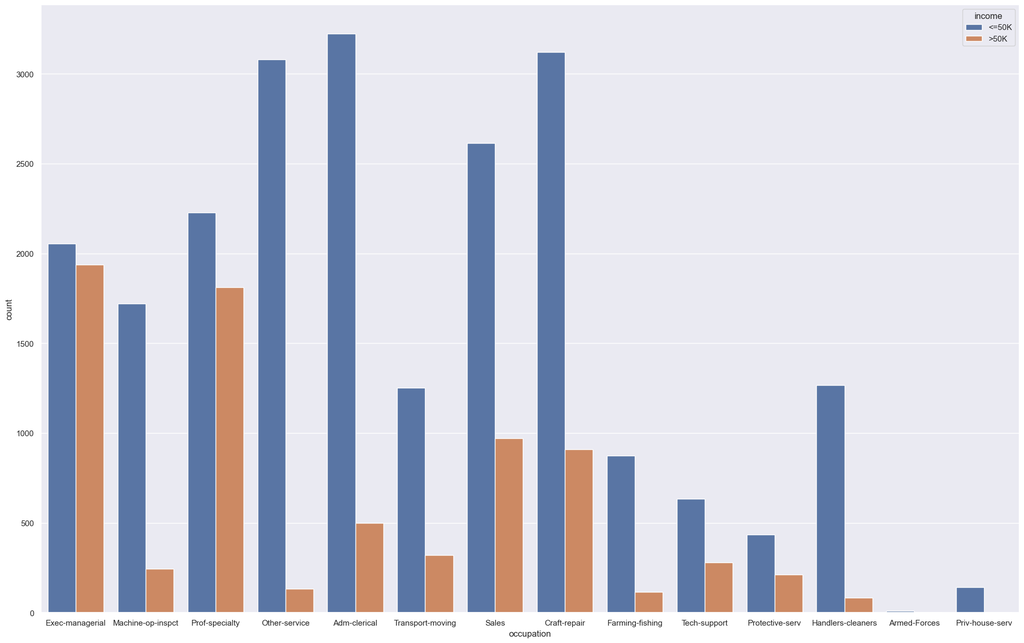

| binary_income_over_$50k occupation | 0 | 1 |
| --- | --- | --- |
| Adm-clerical | 3223 | 498 |
| Craft-repair | 3122 | 908 |
| Other-service | 3080 | 132 |
| Sales | 2614 | 970 |
| Prof-specialty | 2227 | 1811 |
| Exec-managerial | 2055 | 1937 |
| Machine-op-inspct | 1721 | 245 |
| Handlers-cleaners | 1267 | 83 |
| Transport-moving | 1253 | 319 |
| Farming-fishing | 874 | 115 |
| Tech-support | 634 | 278 |
| Protective-serv | 434 | 210 |
| Priv-house-serv | 142 | 1 |
| Armed-Forces | 8 | 1 |

```python
occupation_countplot_table = plot_countplot('occupation', figsize= (24,15))
occupation_countplot_table.sort_values(by=0, ascending = False) # sort by column 0 and go from largest to smallest
```

From the above figure, it's evident that most of the occupations have a considerable amount of more people making <= 50k than people making >= 50k. Except for the occupations, Prof-specialty and Exec-managerial, where the difference is a lot smaller.

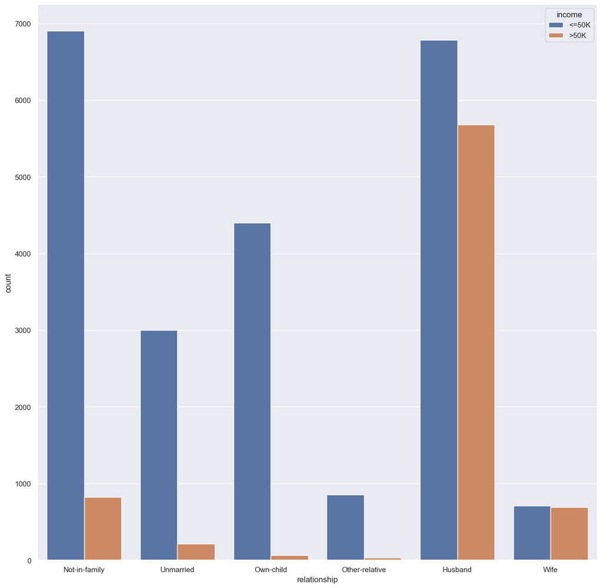

| binary_income_over_$50k relationship | 0 | 1 |
| --- | --- | --- |
| Not-in-family | 6903 | 823 |
| Husband | 6784 | 5679 |
| Own-child | 4402 | 64 |
| Unmarried | 2999 | 213 |
| Other-relative | 854 | 35 |
| Wife | 712 | 694 |

```python
relationship_countplot_table = plot_countplot(col = 'relationship')
relationship_countplot_table.sort_values(by=0, ascending = False) # sort by column 0 and go from largest to smallest
```

The relationship columns represent the individual's relationship inside the household, so it makes sense that the husband and wife relationship is the one with the most amount of people making > 50k as opposed to the other relationship statuses.

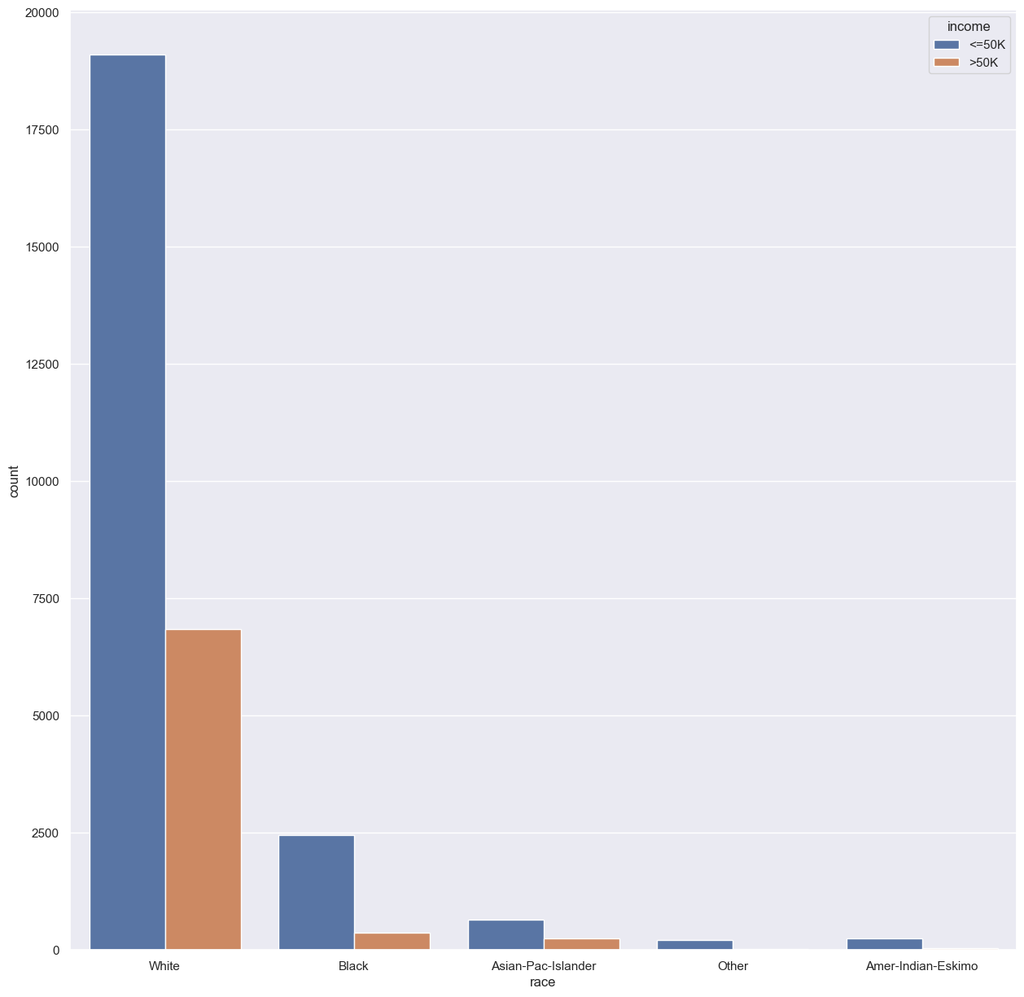

| binary_income_over_$50k race | 0 | 1 |
| --- | --- | --- |
| White | 19094 | 6839 |
| Black | 2451 | 366 |
| Asian-Pac-Islander | 647 | 248 |
| Amer-Indian-Eskimo | 252 | 34 |
| Other | 210 | 21 |

```python
race_countplot_table = plot_countplot(col = 'race')
race_countplot_table.sort_values(by=0, ascending = False) # sort by column 0 and go from largest to smallest
```

Analysis question #10 can now be answered. It is clear the race with the most amount of people making > 50k is the white race and it's also the race with the most amount of people making <= 50k. It's worth noting that I am considering only the frequency and not the percentages, which would be a fairer assessment of which race tends to make more.

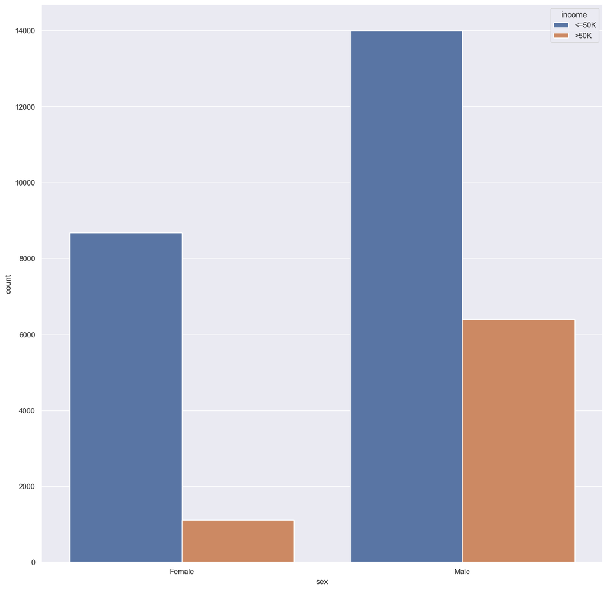

| binary_income_over_$50k sex | 0 | 1 |
| --- | --- | --- |
| Male | 13984 | 6396 |
| Female | 8670 | 1112 |

```python
sex_countplot_table = plot_countplot(col='sex')
sex_countplot_table.sort_values(by=0, ascending = False) # sort by column 0 and go from largest to smallest
```

The above information shows that the sex with the most amount of people who make > 50k and the most of people who make <= 50k is the male sex. This answers analysis question #8. In both groups, there is a considerable amount more people making <= 50k.

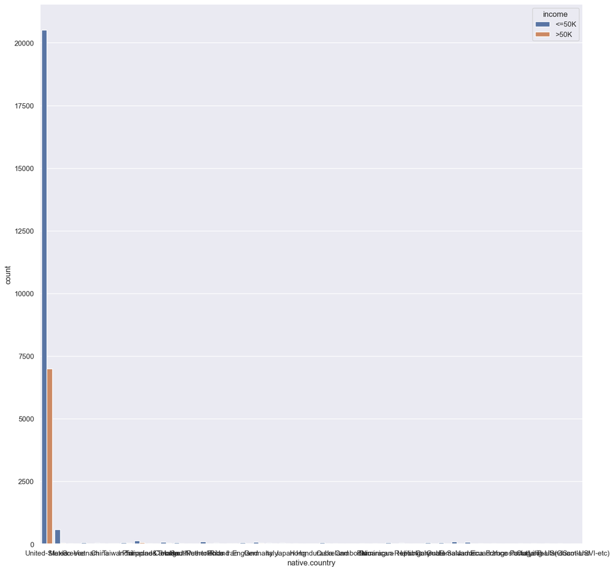

| binary_income_over_$50k native.country | 0 | 1 |
| --- | --- | --- |
| United-States | 20509 | 6995 |
| Mexico | 577 | 33 |
| Philippines | 128 | 60 |
| Puerto-Rico | 97 | 12 |
| El-Salvador | 91 | 9 |
| Germany | 84 | 44 |
| Canada | 71 | 36 |
| Jamaica | 70 | 10 |
| Cuba | 67 | 25 |
| Dominican-Republic | 65 | 2 |
| Guatemala | 60 | 3 |
| India | 60 | 40 |
| Vietnam | 59 | 5 |
| South | 57 | 14 |
| England | 56 | 30 |
| Columbia | 54 | 2 |
| China | 48 | 20 |
| Poland | 45 | 11 |
| Italy | 44 | 24 |
| Haiti | 38 | 4 |
| Japan | 36 | 23 |
| Nicaragua | 31 | 2 |
| Portugal | 30 | 4 |
| Peru | 28 | 2 |
| Iran | 24 | 18 |
| Taiwan | 23 | 19 |
| Ecuador | 23 | 4 |
| Greece | 21 | 8 |
| Ireland | 19 | 5 |
| Trinadad&Tobago | 16 | 2 |
| Laos | 15 | 2 |
| France | 15 | 12 |
| Outlying-US(Guam-USVI-etc) | 14 | 0 |
| Thailand | 14 | 3 |
| Hong | 13 | 6 |
| Cambodia | 11 | 7 |
| Honduras | 11 | 1 |
| Hungary | 10 | 3 |
| Yugoslavia | 10 | 6 |
| Scotland | 9 | 2 |
| Holand-Netherlands | 1 | 0 |

```python
native_country_countplot_table = plot_countplot(col = 'native.country')
native_country_countplot_table.sort_values(by=0, ascending = False) # sort by column 0 and go from largest to smallest
```

There are too many countries in the dataset to properly show on the countplot, but the frequency table shows that the United States has the most amount of people in both income categories. Mexico has the second most amount of people making <= 50k, followed by the Philippines.

### Pivot Tables for Qualtative Columns

```python
workclass_pivot_table = pd.pivot_table(data= adult_census_data, index = ['workclass', 'income'], values= ['age', 'education.num', 'capital.gain', 'capital.loss', 'hours.per.week'])
workclass_pivot_table
```

| workclass | income | age | capital.gain | capital.loss | education.num | hours.per.week |
| --- | --- | --- | --- | --- | --- | --- |
| Federal-gov | <=50K | 40.605536 | 176.503460 | 93.015571 | 10.468858 | 39.982699 |
|  | >50K | 45.701370 | 1870.849315 | 141.369863 | 11.706849 | 43.334247 |
| Local-gov | <=50K | 40.714678 | 166.970508 | 80.163237 | 10.569959 | 39.748971 |
|  | >50K | 44.205255 | 2414.738916 | 182.528736 | 12.154351 | 44.003284 |
| Private | <=50K | 35.106720 | 138.144170 | 49.671051 | 9.438369 | 38.782596 |
|  | >50K | 42.820139 | 3528.184988 | 186.597621 | 11.416120 | 45.493437 |
| Self-emp-inc | <=50K | 43.130802 | 182.476793 | 56.662447 | 10.251055 | 46.966245 |
|  | >50K | 48.316667 | 8467.080000 | 230.010000 | 11.891667 | 50.253333 |
| Self-emp-not-inc | <=50K | 44.451541 | 223.535014 | 61.985434 | 9.680112 | 43.507003 |
|  | >50K | 46.411765 | 6137.133053 | 249.539216 | 11.539216 | 46.745098 |
| State-gov | <=50K | 37.240642 | 139.203209 | 40.529412 | 10.790374 | 37.170053 |
|  | >50K | 45.127907 | 2165.909884 | 191.549419 | 12.869186 | 44.174419 |
| Without-pay | <=50K | 47.785714 | 487.857143 | 0.000000 | 9.071429 | 32.714286 |

Through the above pivot table, there is a trend that the average age for the > 50k group for every workclass is higher than the average age for the <= 50k group of the same workclass. We can also see this same trend with all the other numeric columns; people in the > 50k group have more capital gain, capital loss, higher education levels, and more hours worked per week than their counterparts in the <= 50k group.

```python
education_pivot_table = pd.pivot_table(data= adult_census_data, index = ['education', 'income'], values= ['age', 'education.num', 'capital.gain', 'capital.loss', 'hours.per.week'])
education_pivot_table
```

| education | income | age | capital.gain | capital.loss | education.num | hours.per.week |
| --- | --- | --- | --- | --- | --- | --- |
| 10th | <=50K | 36.980289 | 97.618922 | 42.540079 | 6.0 | 36.988173 |
|  | >50K | 49.728814 | 4243.423729 | 316.728814 | 6.0 | 43.610169 |
| 11th | <=50K | 31.731041 | 80.803842 | 43.089990 | 7.0 | 33.555106 |
|  | >50K | 42.966102 | 2503.406780 | 210.915254 | 7.0 | 44.898305 |
| 12th | <=50K | 30.899425 | 89.183908 | 30.321839 | 8.0 | 34.939655 |
|  | >50K | 45.379310 | 2381.310345 | 63.724138 | 8.0 | 44.793103 |
| 1st-4th | <=50K | 44.317241 | 65.634483 | 55.993103 | 2.0 | 37.944828 |
|  | >50K | 52.000000 | 1281.333333 | 0.000000 | 2.0 | 48.833333 |
| 5th-6th | <=50K | 41.554348 | 105.786232 | 67.797101 | 3.0 | 38.521739 |
|  | >50K | 43.833333 | 1647.833333 | 157.250000 | 3.0 | 45.166667 |
| 7th-8th | <=50K | 47.260536 | 185.296935 | 67.026820 | 4.0 | 39.609195 |
|  | >50K | 53.171429 | 1130.714286 | 54.342857 | 4.0 | 47.914286 |
| 9th | <=50K | 39.793023 | 130.300000 | 21.179070 | 5.0 | 38.413953 |
|  | >50K | 49.080000 | 4207.080000 | 163.160000 | 5.0 | 44.840000 |
| Assoc-acdm | <=50K | 35.902926 | 114.837766 | 65.966755 | 12.0 | 39.953457 |
|  | >50K | 41.351562 | 1847.667969 | 177.835938 | 12.0 | 44.800781 |
| Assoc-voc | <=50K | 36.741433 | 194.452752 | 46.686397 | 11.0 | 41.298027 |
|  | >50K | 42.459302 | 2257.125000 | 136.020349 | 11.0 | 43.790698 |
| Bachelors | <=50K | 35.893763 | 165.098355 | 59.048321 | 13.0 | 40.920493 |
|  | >50K | 42.412982 | 3889.806209 | 198.828786 | 13.0 | 45.731891 |
| Doctorate | <=50K | 44.357895 | 248.336842 | 51.884211 | 16.0 | 46.694737 |
|  | >50K | 48.071429 | 6654.185714 | 337.610714 | 16.0 | 48.217857 |
| HS-grad | <=50K | 37.451417 | 153.723945 | 53.116502 | 9.0 | 40.222303 |
|  | >50K | 44.690167 | 2804.876314 | 160.666048 | 9.0 | 45.210884 |
| Masters | <=50K | 41.895628 | 293.393512 | 83.358251 | 14.0 | 41.703808 |
|  | >50K | 45.164488 | 4300.569717 | 240.202614 | 14.0 | 46.200436 |
| Preschool | <=50K | 41.288889 | 1018.177778 | 75.355556 | 1.0 | 36.866667 |
| Prof-school | <=50K | 42.882353 | 156.375000 | 95.808824 | 15.0 | 43.816176 |
|  | >50K | 44.706897 | 14274.081281 | 280.923645 | 15.0 | 49.352217 |
| Some-college | <=50K | 34.196181 | 126.955447 | 50.589105 | 10.0 | 37.999064 |
|  | >50K | 43.889222 | 2442.908683 | 157.123503 | 10.0 | 45.056886 |

```python
marital_status_pivot_table = pd.pivot_table(data= adult_census_data, index = ['marital.status', 'income'], values= ['age', 'education.num', 'capital.gain', 'capital.loss', 'hours.per.week'])
marital_status_pivot_table
```

| marital.status | income | age | capital.gain | capital.loss | education.num | hours.per.week |
| --- | --- | --- | --- | --- | --- | --- |
| Divorced | <=50K | 42.566986 | 142.161350 | 57.413610 | 9.852472 | 40.808612 |
|  | >50K | 45.435841 | 5838.396018 | 141.207965 | 11.918142 | 47.460177 |
| Married-AF-spouse | <=50K | 30.090909 | 0.000000 | 0.000000 | 9.363636 | 45.727273 |
|  | >50K | 31.300000 | 729.800000 | 0.000000 | 11.000000 | 42.600000 |
| Married-civ-spouse | <=50K | 41.636968 | 219.403861 | 61.375815 | 9.360031 | 42.326768 |
|  | >50K | 44.127989 | 3605.772152 | 198.067042 | 11.517425 | 45.558681 |
| Married-spouse-absent | <=50K | 39.631268 | 113.784661 | 42.628319 | 8.932153 | 39.368732 |
|  | >50K | 47.645161 | 6600.580645 | 130.193548 | 12.032258 | 45.225806 |
| Never-married | <=50K | 27.974395 | 98.092589 | 45.740169 | 9.881698 | 36.756590 |
|  | >50K | 38.053191 | 6011.123404 | 179.006383 | 12.534043 | 46.674468 |
| Separated | <=50K | 39.174112 | 117.262314 | 48.349370 | 9.174112 | 39.217640 |
|  | >50K | 42.348485 | 6614.727273 | 232.621212 | 12.166667 | 46.212121 |
| Widowed | <=50K | 57.693440 | 143.764391 | 59.281124 | 8.987952 | 33.599732 |
|  | >50K | 58.287500 | 4726.162500 | 248.762500 | 10.962500 | 42.100000 |

A trend that's seen in the above pivot table is that for the marital status groups that have at one point been married or are still currently married differ by a small amount of years in their mean age for the income groups, except for the Married-spouse-absent. The <= 50k group of the Married-spouse-absent marital status has a mean age of 40 years old, whereas the > 50k group has a mean age of 48 years old

```python
occupation_pivot_table = pd.pivot_table(data= adult_census_data, index = ['occupation', 'income'], values= ['age', 'education.num', 'capital.gain', 'capital.loss', 'hours.per.week'])
occupation_pivot_table
```

| occupation | income | age | capital.gain | capital.loss | education.num | hours.per.week |
| --- | --- | --- | --- | --- | --- | --- |
| Adm-clerical | <=50K | 36.031958 | 138.317096 | 50.753025 | 10.013962 | 37.054918 |
|  | >50K | 43.299197 | 2819.082329 | 119.753012 | 10.716867 | 40.839357 |
| Armed-Forces | <=50K | 28.250000 | 0.000000 | 0.000000 | 9.625000 | 40.750000 |
|  | >50K | 46.000000 | 0.000000 | 1887.000000 | 14.000000 | 40.000000 |
| Craft-repair | <=50K | 37.592569 | 148.671685 | 67.058616 | 8.914478 | 41.612108 |
|  | >50K | 43.735683 | 2407.403084 | 153.394273 | 9.817181 | 44.656388 |
| Exec-managerial | <=50K | 39.628224 | 184.769830 | 59.030170 | 10.825304 | 42.760097 |
|  | >50K | 44.893650 | 4307.764068 | 224.303562 | 12.089830 | 47.308209 |
| Farming-fishing | <=50K | 40.487414 | 266.659039 | 43.516018 | 8.431350 | 46.041190 |
|  | >50K | 47.060870 | 3070.678261 | 214.469565 | 10.008696 | 54.208696 |
| Handlers-cleaners | <=50K | 31.385951 | 112.342541 | 36.377269 | 8.444357 | 37.581689 |
|  | >50K | 43.240964 | 2483.746988 | 163.939759 | 9.277108 | 42.349398 |
| Machine-op-inspct | <=50K | 37.038350 | 155.248693 | 45.747240 | 8.350959 | 40.336432 |
|  | >50K | 42.297959 | 1507.987755 | 148.293878 | 9.351020 | 43.310204 |
| Other-service | <=50K | 34.628896 | 78.926948 | 32.992857 | 8.720455 | 34.250000 |
|  | >50K | 41.371212 | 2579.871212 | 127.439394 | 10.136364 | 42.901515 |
| Priv-house-serv | <=50K | 42.000000 | 115.929577 | 22.507042 | 7.183099 | 32.781690 |
|  | >50K | 47.000000 | 25236.000000 | 0.000000 | 13.000000 | 35.000000 |
| Prof-specialty | <=50K | 37.911540 | 193.944320 | 66.916031 | 12.365963 | 40.071846 |
|  | >50K | 43.600221 | 5821.582551 | 221.925456 | 13.536720 | 45.207068 |
| Protective-serv | <=50K | 37.688940 | 247.887097 | 46.822581 | 9.845622 | 41.525346 |
|  | >50K | 41.480952 | 1676.061905 | 145.323810 | 10.900000 | 45.576190 |
| Sales | <=50K | 34.802984 | 135.007651 | 62.429610 | 9.902448 | 38.276970 |
|  | >50K | 44.358763 | 4471.389691 | 198.073196 | 11.364948 | 47.463918 |
| Tech-support | <=50K | 34.399054 | 194.793375 | 54.121451 | 10.839117 | 38.597792 |
|  | >50K | 43.140288 | 1747.528777 | 199.089928 | 11.258993 | 41.471223 |
| Transport-moving | <=50K | 39.166800 | 131.960096 | 65.486832 | 8.636073 | 43.619314 |
|  | >50K | 44.517241 | 1936.366771 | 150.689655 | 9.206897 | 48.699060 |

An intersting thing to to note from the above pivot table is that none of the income groups for Armed-Forces have any capital gain and the amount of hours per week are almost the same.

```python
relationship_pivot_table = pd.pivot_table(data= adult_census_data, index = ['relationship', 'income'], values= ['age', 'education.num', 'capital.gain', 'capital.loss', 'hours.per.week'])
relationship_pivot_table
```

| relationship | income | age | capital.gain | capital.loss | education.num | hours.per.week |
| --- | --- | --- | --- | --- | --- | --- |
| Husband | <=50K | 42.131191 | 206.296285 | 62.477889 | 9.355248 | 43.003096 |
|  | >50K | 44.561719 | 3691.779010 | 200.874274 | 11.527558 | 46.434407 |
| Not-in-family | <=50K | 37.327973 | 138.764305 | 65.160220 | 10.144865 | 40.380559 |
|  | >50K | 42.701094 | 5940.450790 | 164.340219 | 12.262454 | 46.972053 |
| Other-relative | <=50K | 32.853630 | 129.375878 | 40.624122 | 8.679157 | 37.135831 |
|  | >50K | 42.000000 | 2804.428571 | 398.428571 | 10.800000 | 42.828571 |
| Own-child | <=50K | 25.028169 | 75.630622 | 37.754884 | 9.504998 | 33.208996 |
|  | >50K | 36.046875 | 6102.859375 | 129.859375 | 11.156250 | 43.281250 |
| Unmarried | <=50K | 39.948983 | 123.621874 | 32.652884 | 9.528843 | 38.950984 |
|  | >50K | 45.779343 | 5411.131455 | 150.173709 | 11.868545 | 46.201878 |
| Wife | <=50K | 39.028090 | 282.980337 | 53.853933 | 9.567416 | 36.810393 |
|  | >50K | 40.789625 | 2980.096542 | 179.279539 | 11.475504 | 38.466859 |

For all of the relationship groups, the > 50k group has made a higher average capital gain amount.

```python
race_pivot_table = pd.pivot_table(data= adult_census_data, index = ['race', 'income'], values= ['age', 'education.num', 'capital.gain', 'capital.loss', 'hours.per.week'])
race_pivot_table
```

| race | income | age | capital.gain | capital.loss | education.num | hours.per.week |
| --- | --- | --- | --- | --- | --- | --- |
| Amer-Indian-Eskimo | <=50K | 36.376984 | 203.535714 | 22.234127 | 9.123016 | 39.781746 |
|  | >50K | 39.411765 | 4045.647059 | 147.823529 | 11.088235 | 45.205882 |
| Asian-Pac-Islander | <=50K | 36.151468 | 118.278207 | 48.755796 | 10.496136 | 38.925811 |
|  | >50K | 42.500000 | 4398.750000 | 203.677419 | 12.407258 | 44.608871 |
| Black | <=50K | 36.989392 | 107.908201 | 40.806610 | 9.306814 | 37.798450 |
|  | >50K | 43.696721 | 3931.745902 | 159.806011 | 11.030055 | 44.540984 |
| Other | <=50K | 32.780952 | 81.719048 | 46.338095 | 8.400000 | 39.633333 |
|  | >50K | 41.809524 | 10850.000000 | 89.857143 | 11.523810 | 44.904762 |
| White | <=50K | 36.619723 | 155.210014 | 55.719860 | 9.661307 | 39.553053 |
|  | >50K | 44.055271 | 3899.515865 | 195.754642 | 11.611054 | 45.813715 |

The race with the highest mean age for the > 50k group, which despite having the most amount of people who are making > 50k. The races with fewer representation in the dataset have younger mean ages for their > 50k group.

```python
sex_pivot_table = pd.pivot_table(data= adult_census_data, index = ['sex', 'income'], values= ['age', 'education.num', 'capital.gain', 'capital.loss', 'hours.per.week'])
sex_pivot_table
```

| sex | income | age | capital.gain | capital.loss | education.num | hours.per.week |
| --- | --- | --- | --- | --- | --- | --- |
| Female | <=50K | 36.231719 | 119.394348 | 46.251557 | 9.878777 | 36.423645 |
|  | >50K | 41.964928 | 4084.820144 | 175.451439 | 11.812950 | 40.897482 |
| Male | <=50K | 36.841390 | 167.183352 | 57.909754 | 9.474328 | 41.162042 |
|  | >50K | 44.305816 | 3912.098186 | 196.932145 | 11.570513 | 46.542683 |

The above pivot table allows me to answer the analysis question #9. For males who make > 50k, the average age is 44 years old, rounding to the nearest whole number. For females who make > 50k, the average age is 42 years old, rounding to the nearest whole number. On a side note, both males and females in the <= 50k group have the same average age of 36 without rounding, which is opposite of what we see with the > 50k group of females and males.

```python
native_country_pivot_table = pd.pivot_table(data= adult_census_data, index = ['native.country', 'income'], values= ['age', 'education.num', 'capital.gain', 'capital.loss', 'hours.per.week'])
native_country_pivot_table
```

| native.country | income | age | capital.gain | capital.loss | education.num | hours.per.week |
| --- | --- | --- | --- | --- | --- | --- |
| Cambodia | <=50K | 37.272727 | 543.545455 | 170.545455 | 7.727273 | 41.545455 |
|  | >50K | 41.428571 | 1935.714286 | 0.000000 | 10.285714 | 40.000000 |
| Canada | <=50K | 40.098592 | 70.605634 | 168.070423 | 10.239437 | 38.704225 |
|  | >50K | 44.305556 | 4659.583333 | 105.250000 | 11.527778 | 46.944444 |
| China | <=50K | 41.270833 | 119.041667 | 108.187500 | 10.354167 | 38.541667 |
| ... | ... | ... | ... | ... | ... | ... |
| United-States | >50K | 44.000429 | 3965.694353 | 194.689207 | 11.586276 | 45.750536 |
| Vietnam | <=50K | 33.203390 | 252.406780 | 99.135593 | 9.508475 | 38.152542 |
|  | >50K | 35.400000 | 5873.600000 | 0.000000 | 9.600000 | 39.200000 |
| Yugoslavia | <=50K | 38.000000 | 0.000000 | 0.000000 | 9.700000 | 41.600000 |
|  | >50K | 40.166667 | 926.000000 | 0.000000 | 10.333333 | 49.500000 |

80 rows × 5 columns

Thailand's > 50k group has the highest average hours worked per week with 58 hours per week!

# Testing Hypothesis

Now that we have answered our analysis questions let's do some hypothesis test for some of the observations we had for the questions to see if they are statistcally significant and not by chance

Our first hypothesis test will help to confirm whether or not our observation for analysis question #1 is not by chance.

Let:

$\mu_0$: means hour per week for the > 50k group

$\mu_1$: mean hours per week for the <= 50k group

Null Hypothesis: Both groups have the same average amount of hours worked per week, $\mu_0 = \mu_1$

Alternate Hypothesis: The groups don't have the same average amount of hours worked per week, $\mu_0 \neq \mu_1$

For this, we will use a Two-Sample Student T-Test:

- Test whether two independent samples are significantly different
- Assumptions:
  - Observations in each sample are independent and identically distributed (iid).
  - Observations in each sample are normally distributed.
  - Observations in each sample have the same variance.

```python
from scipy.stats import ttest_ind

less_than_equal_to_50k_group = adult_census_data[adult_census_data["binary_income_over_$50k"] == 0]["hours.per.week"]
greater_than_50k_group  = adult_census_data[adult_census_data["binary_income_over_$50k"] == 1]["hours.per.week"]
stat, p = ttest_ind(less_than_equal_to_50k_group, greater_than_50k_group)
if p > 0.05:
  print("Fail to reject null hypothesis")
else:
  print("Reject null hypothesis, there is evidence that the groups don't have the same average amount of hours worked per week")
```

```
Reject null hypothesis, there is evidence that the groups don't have the same average amount of hours worked per week
```

We were able to reject the null hypothesis, meaning that the differnce in the average hours worked per week for the two income groups is statistically significant. Our observation of the two groups having different means for the hours worked per week is likely to not be by chance.

Our second hypothesis test will be for the analysis question #9 is not by chance.

Let:

$\mu_0$: mean age for males a part of the > 50k group

$\mu_1$: mean age for females a part of the > 50k group

Null Hypothesis: Both groups are the same age, $\mu_0 = \mu_1$

Alternate Hypothesis: The groups don't share the same age, $\mu_0 \neq \mu_1$

For this, we will use a Two-Sample Student T-Test:

- Test whether two independent samples are significantly different
- Assumptions:
  - Observations in each sample are independent and identically distributed (iid).
  - Observations in each sample are normally distributed.
  - Observations in each sample have the same variance.

```python
female_group = adult_census_data[(adult_census_data['binary_income_over_$50k'] == 1) & (adult_census_data['sex'] == 'Female')]['age']
male_group  = adult_census_data[(adult_census_data['binary_income_over_$50k'] == 1) & (adult_census_data['sex'] == 'Male')]['age']
stat, p = ttest_ind(female_group, male_group)
if p > 0.05:
  print("Fail to reject null hypothesis")
else:
  print("Reject null hypothesis, there is evidence that the groups don't share the same mean age")
```

```
Reject null hypothesis, there is evidence that the groups don't share the same mean age
```

We were able to reject the null hypothesis. This means that our observation for analysis question #9 is in line with the hypothesis test since we found that the average age for women a part of the > 50k group was different than the average age of males a part of the > 50k group.

# Conclusions

### Analysis question #1

Q: What was the average number of hours worked for a person who made > 50k, and what was the average number of hours worked for a person who made <= to 50k?

A: The average number of hours worked for a person who made > 50k is 45.7 hours worked per week. The average number of hours worked for a person who made <= 50k is 39.3 hours worked per week.

### Analysis question #2

Q: For a person whose highest education level is only high school, who makes > 50k, if any, what is the average number of hours worked?

### Analysis question #3

Q: What is the average education level for a person making > 50k and what is the average education level for a person making <= 50k?

A: The average education number for a person making > 50k is 12 if we round up to the nearest number, which is equivalent to Assoc-acdm in terms of education level. The average education number for a person making <= 50k is 10, meaning they have some college.

### Analysis question #4

Q: What is the correlation between capital gain and whether or not a person makes over 50k?

A: The correlation between capital gain and a person making over > 50k is 0.221, indicating a weak positive relationship. This makes sense since not everyone who is making money from investments might be making a profit compared to their losses, or the money made isn't much. The correlation between capital gain and a person making <= 50k is -0.221 indicating, a weak negative relationship.

### Analysis question #5

Q: What marital status has the most people making over 50k, and what marital status has the most people making less than or equal to 50k?

A: The marital status with the most amount of people making > 50k is married-civ-spouse. The marital status with the most amount of people making <= 50k is Never-married.

### Analysis question #6

Q: What numerical column has the highest amount of correlation, in terms of magnitude, with whether or not a person made > 50k and whether they make <= 50k?

A: The column with the highest amount of correlation, in terms of magnitude, for both binary columns is education.num with a value of 0.335. This is a weak relationship, indicating that as a person's education level becomes higher, they are more likely to make >50k. If we look at it from the perspective of making <= 50k, -0.335 indicates it indicates that as a person's education level becomes higher than they are less likely to make <= 50k.

### Analysis question #7

Q: What workclass has the most people making <= 50k, and what work class has the most people making > 50k?

A: The private workclass has the most amount of people making > 50k, as well as the most amount of people making less <= 50k.

### Analysis question #8

Q: Do women or men tend to make > 50k more than the other, and do women or men tend to make <= 50k?

A: The sex with the most amount of people who make > 50k and the most of people who make <= 50k is the male sex.

### Analysis question #9

Q: What is the average age of men who make > 50k, and what is the average age of women who make > 50k?

A: For males who make > 50k, the average age is 44 years old, rounding to the nearest whole number. For females who make > 50k, the average age is 42 years old, rounding to the nearest whole number.

### Analysis question #10

Q: Which race tends to make > 50k, more than the other races, and what race tends to make <= 50k more than the other races?

A: The race with the most amount of people making > 50k is the white race, and it's also the race with the most amount of people making <= 50k. It's worth noting that I am considering only the frequency and not the percentages, which would be a fairer assessment of which race tends to make more.